# CIS_544_hw3_Chen

Chen

November 9, 2016

## Problem 1

In this problem, you will develop a model to predict whether a given car gets high or low gas mileage based on the Auto data set.

Create a binary variable, mpg01, that contains a 1 if mpg contains a value above its median, and a 0 if mpg contains a value below its median. You can compute the median using the median() function. one possiblw way to do this, it using the function ifelse()).

```r
library(MASS) ##load "MASS" library which include "Auto" Dataset.
library(ISLR)
attach(Auto) ##Use the "Auto" Dataset.
Auto$mpg01 <- ifelse(Auto$mpg > median(Auto$mpg),1,0)   ##Create the binary variable "mpg1" that contains a 1 if mpg value above the median and a 0 if mpg value below the median.
```

Explore the data graphically in order to investigate the association between mpg01 and the other features. Which of the other features seem most likely to be useful in predicting mpg01? Scatterplots and boxplots may be useful tools to answer this question. Describe your findings.

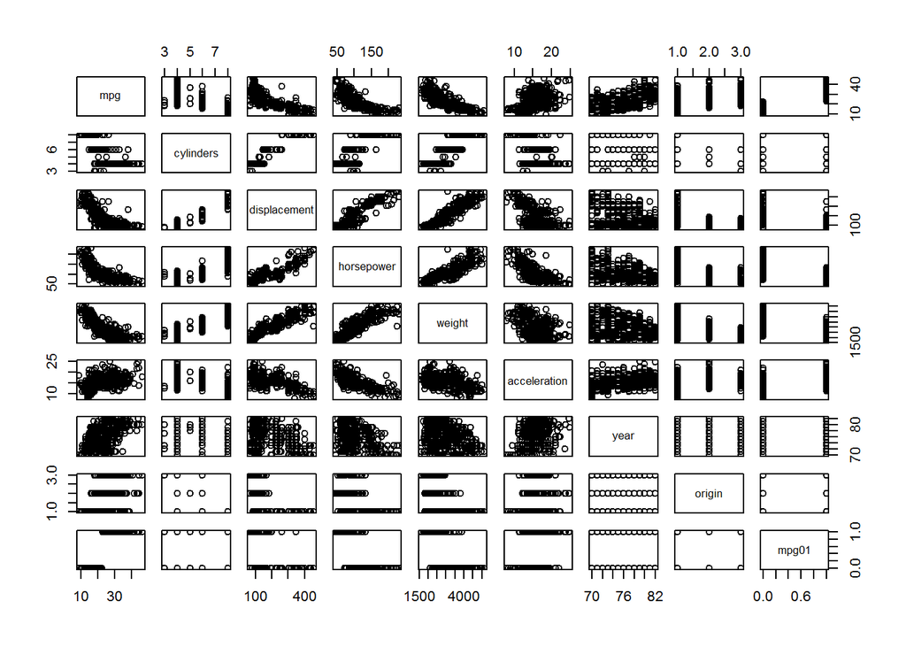

```r
pairs(Auto[,-9])  ##Make the Scaatterplots that show the relationship between "mpg1" with other attribute.
```

Split the data into a training set and a test set.

```r
set.seed(1)
rands <- rnorm(nrow(Auto))
test <- rands > quantile(rands,0.75)
train <- !test
Auto.train <- Auto[train,]
Auto.test <- Auto[test,]

## I don't understand which does those code mean.
```

Perform LDA on the training data in order to predict mpg01 using the variables that seemed most associated with mpg01

```r
lda.fit = lda(mpg01 ~ horsepower+weight+acceleration, data=Auto.train)
lda.fit  ## Making the LDA(linear discriminant analysis) "mpg1" which respond to "horsepower" ,"acceleration" and "weight" variable.
```

```
## Call:
## lda(mpg01 ~ horsepower + weight + acceleration, data = Auto.train)
##
## Prior probabilities of groups:
##         0         1
## 0.5170068 0.4829932
##
## Group means:
##   horsepower   weight acceleration
## 0  129.77632 3635.020     14.66645
## 1   78.62676 2328.627     16.57535
##
## Coefficients of linear discriminants:
##                        LD1
## horsepower    0.0006106698
## weight       -0.0018255056
## acceleration  0.0234836834
```

What is the test error of the model?

```r
lda.class=predict(lda.fit,Auto.test)$class
table(lda.class,Auto.test$mpg01)
```

```
##
## lda.class  0  1
##         0 33  4
##         1 11 50
```

```r
mean(lda.class==Auto.test$mpg01)  ##  make the prediction for the "mpg01".
```

```
## [1] 0.8469388
```

```r
##  For the problem 1, some of the answer is I make the reference from the https://github.com/jstjohn/IntroToStatisticalLearningR-/blob/master/R_Exercises/Exercise3/Exercise3.Rmd website, and some of it I don't understand.
```